# Analysis on Turkey’s Debit/Credit Card Expenditure

Baran Dogru - IE360 - Spring 2020

# Introduction

The aim of this report is to perform some analysis on the last 6 year’s debit/credit card expenditure data which was obtained from the Central Bank of the Republic of Turkey. The source code can be found [here](https://github.com/BU-IE-360/spring20-barandogru/tree/master/HW1).

The following are the datasets that will be used to provide insights:

1. Total credit/debit card expenditure amount (Thousand TRY)
2. Total number of credit/debit card transactions
3. USD/TRY exchange rate
4. Consumer price index of Turkey

The main goal is to examine the behaviour of the total credit/debit card expenditure amount with the help of other datasets. (All of these data belongs to the Central Bank of the Republic of Turkey.)

## Preparations

Preparation part consists of installing the required packages, reading and taking a first look at the data.

### Installing the packages:

```r
# including the required packages
library(readxl)
library(dplyr)
library(ggplot2)
library(lubridate)
library(xts)
```

### Reading the data:

```r
# reading the data
total_expenditure <- read_xlsx('totalcardexpenditure.xlsx')
num_transactions <- read_xlsx('totalnumoftransactions.xlsx')
usd_try <- read_xlsx('usdcurrency.xlsx')
turkey_cpi <- read_xlsx('turkeycpi.xlsx')
```

### First look at the data:

1. Total credit/debit card expenditure amount (Thousand TRY)

```r
head(total_expenditure)
```

```
## # A tibble: 6 x 2
##   Tarih      `TP KKHARTUT KT1`
##   <chr>                  <dbl>
## 1 03-01-2014                NA
## 2 10-01-2014                NA
## 3 17-01-2014                NA
## 4 24-01-2014                NA
## 5 31-01-2014                NA
## 6 07-02-2014                NA
```

```r
summary(total_expenditure)
```

```
##     Tarih           TP KKHARTUT KT1
##  Length:328         Min.   : 7070685
##  Class :character   1st Qu.:10779142
##  Mode  :character   Median :12803828
##                     Mean   :13578570
##                     3rd Qu.:16180676
##                     Max.   :24369424
##                     NA's   :9
```

2. Total number of credit/debit card transactions

```r
head(num_transactions)
```

```
## # A tibble: 6 x 3
##   Tarih      `TP KKISLADE KA1` ...3
##   <chr>      <chr>             <chr>
## 1 03-01-2014 <NA>              <NA>
## 2 10-01-2014 <NA>              <NA>
## 3 17-01-2014 <NA>              <NA>
## 4 24-01-2014 <NA>              <NA>
## 5 31-01-2014 <NA>              <NA>
## 6 07-02-2014 <NA>              <NA>
```

```r
summary(num_transactions)
```

```
##     Tarih           TP KKISLADE KA1        ...3
##  Length:336         Length:336         Length:336
##  Class :character   Class :character   Class :character
##  Mode  :character   Mode  :character   Mode  :character
```

3. USD/TRY exchange rate

```r
head(usd_try)
```

```
## # A tibble: 6 x 3
##   Tarih      `TP DK USD A YTL` ...3
##   <chr>                  <dbl> <lgl>
## 1 01-01-2014             NA    NA
## 2 02-01-2014              2.13 NA
## 3 03-01-2014              2.17 NA
## 4 04-01-2014             NA    NA
## 5 05-01-2014             NA    NA
## 6 06-01-2014              2.17 NA
```

```r
summary(usd_try)
```

```
##     Tarih           TP DK USD A YTL   ...3
##  Length:2307        Min.   :2.071   Mode:logical
##  Class :character   1st Qu.:2.767   NA's:2307
##  Mode  :character   Median :3.522
##                     Mean   :3.796
##                     3rd Qu.:5.281
##                     Max.   :6.907
##                     NA's   :722
```

4. Consumer price index of Turkey

```r
head(turkey_cpi)
```

```
## # A tibble: 6 x 3
##   Tarih   `TP FG J0` ...3
##   <chr>   <chr>      <chr>
## 1 2014-01 233.54     <NA>
## 2 2014-02 234.54     <NA>
## 3 2014-03 237.18     <NA>
## 4 2014-04 240.37     <NA>
## 5 2014-05 241.32     <NA>
## 6 2014-06 242.07     <NA>
```

```r
summary(turkey_cpi)
```

```
##     Tarih             TP FG J0             ...3
##  Length:87          Length:87          Length:87
##  Class :character   Class :character   Class :character
##  Mode  :character   Mode  :character   Mode  :character
```

Here are the problems that draws the attention after the first look into the data:

- There are some missing values in `total_expenditure` and `num_transactions` datasets at the beginning because their recordings began on 2014-03-07.
- There are some unnecessary columns in 3 of these datasets.
- Most of the columns have nonsense names and again most them are not in the right data type.
- USD-TRY exchange rate data have `NA` values at the weekends.

To fix these problems some data manipulations have to be done.

# Data Manipulations

Data manipulations for each dataset can be found below.

1. Total credit/debit card expenditure amount (Thousand TRY)

```r
total_expenditure <- total_expenditure %>%
                      rename(Date = 'Tarih', Amount = 'TP KKHARTUT KT1') %>%
                      filter(!is.na(Date) & !is.na(Amount))
total_expenditure$Date <- as.Date(total_expenditure$Date, format='%d-%m-%Y')
head(total_expenditure)
```

```
## # A tibble: 6 x 2
##   Date        Amount
##   <date>       <dbl>
## 1 2014-03-07 8004400
## 2 2014-03-14 8650779
## 3 2014-03-21 8501345
## 4 2014-03-28 8559196
## 5 2014-04-04 8176410
## 6 2014-04-11 8771625
```

2. Total number of credit/debit card transactions

```r
num_transactions <- num_transactions %>%
                      rename(Date = 'Tarih', Number = 'TP KKISLADE KA1') %>%
                      select(Date, Number) %>%
                      filter(!is.na(Date) & !is.na(Number)) %>%
                      slice(1:319)
num_transactions$Date <- as.Date(num_transactions$Date, format='%d-%m-%Y')
num_transactions$Number <- as.numeric(num_transactions$Number)
head(num_transactions)
```

```
## # A tibble: 6 x 2
##   Date         Number
##   <date>        <dbl>
## 1 2014-03-07 65962973
## 2 2014-03-14 69238515
## 3 2014-03-21 71510062
## 4 2014-03-28 71276145
## 5 2014-04-04 66492495
## 6 2014-04-11 70694670
```

3. USD/TRY exchange rate

```r
usd_try <- usd_try %>%
            rename(Date = 'Tarih', Currency = 'TP DK USD A YTL') %>%
            select(Date, Currency) %>%
            slice(2:2299) %>%
            mutate(USDTRY = na.locf(Currency)) %>%
            select(Date, USDTRY)
usd_try$Date <- as.Date(usd_try$Date, format='%d-%m-%Y')
head(usd_try)
```

```
## # A tibble: 6 x 2
##   Date       USDTRY
##   <date>      <dbl>
## 1 2014-01-02   2.13
## 2 2014-01-03   2.17
## 3 2014-01-04   2.17
## 4 2014-01-05   2.17
## 5 2014-01-06   2.17
## 6 2014-01-07   2.19
```

4. Consumer price index of Turkey

```r
turkey_cpi <- turkey_cpi %>%
            rename(Date = 'Tarih', CPI = 'TP FG J0') %>%
            select(Date, CPI) %>%
            slice(1:75)
turkey_cpi$Date <- as.yearmon(turkey_cpi$Date, format='%Y-%m')
turkey_cpi$CPI <- as.numeric(turkey_cpi$CPI)
head(turkey_cpi)
```

```
## # A tibble: 6 x 2
##   Date        CPI
##   <yearmon> <dbl>
## 1 Jan 2014   234.
## 2 Feb 2014   235.
## 3 Mar 2014   237.
## 4 Apr 2014   240.
## 5 May 2014   241.
## 6 Jun 2014   242.
```

At this moment datasets are ready to be used for the analysis.

# Analysis

## Number of Transactions Made

The first question that can be answered in this analysis is that whether there is a positive correlation between the amount spent and the number of transactions. Firstly, these two variables have to be plotted together. To achieve that these two data frames should be merged.

```r
amount_with_transactions <- merge(total_expenditure, num_transactions, by = 'Date')
amount_with_transactions <- amount_with_transactions %>%
                        mutate(Amount_Per_Transaction = Amount * 1000 / Number)
```

There is also a new column called `Amount_Per_Transaction` which represents the average amount spent per transaction.

This data frame should be converted to an xts object.

```r
amount_transaction_xts <- xts(select(amount_with_transactions, -c(Date)),
                              order.by = amount_with_transactions$Date)
```

Now, the the object is ready to be plotted.

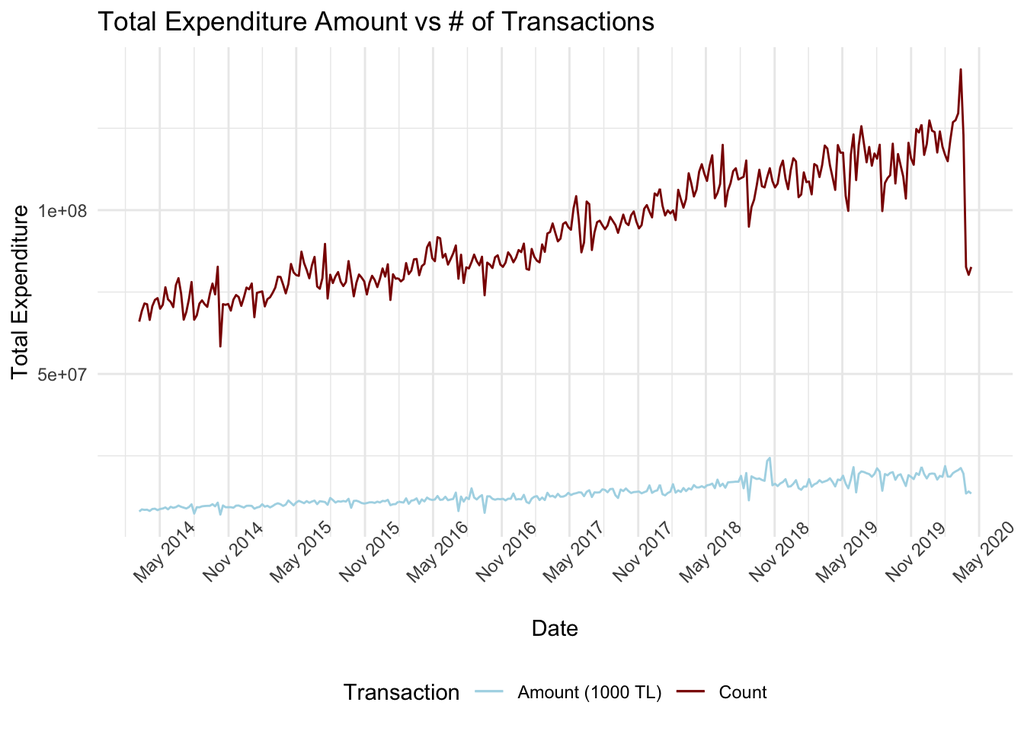

Figure 1: Amount vs Count

By looking at the Figure 1, one can conclude that both of these variables tend to have a positive trend throughout this period. The correlation between these two variables are:

```r
cor(amount_transaction_xts$Amount, amount_transaction_xts$Number)
```

```
##           Number
## Amount 0.9433496
```

This value shows that there is a highly positive correlation between these two.

One last interesting insight from this part is to check whether average amount spent per transaction is increasing or not. The plot for this variable:

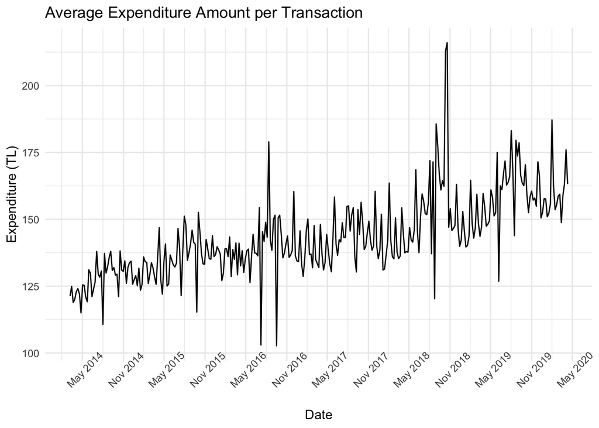

Figure 2: Money Spent per Transaction

By looking at the Figure 2, there seems to be an upwards trend over time.

## USD/TRY Exchange Rate

Firstly, xts objects corresponding to total expenditure amount and USD-TRY exchange rate datasets should be created.

```r
expenditure_xts <- xts(select(total_expenditure, Amount), order.by = total_expenditure$Date)
usdtry_xts <- xts(select(usd_try, USDTRY), order.by = usd_try$Date)
```

To have a look at these objects,

```r
head(expenditure_xts)
```

```
##             Amount
## 2014-03-07 8004400
## 2014-03-14 8650779
## 2014-03-21 8501345
## 2014-03-28 8559196
## 2014-04-04 8176410
## 2014-04-11 8771625
```

```r
head(usdtry_xts)
```

```
##            USDTRY
## 2014-01-02 2.1304
## 2014-01-03 2.1718
## 2014-01-04 2.1718
## 2014-01-05 2.1718
## 2014-01-06 2.1687
## 2014-01-07 2.1878
```

As one can see, `expenditure_xts` is a weekly data however `usdtry_xts` is a daily one. To be able to merge these objects, they have to have the same indices. To achieve that daily data can be averaged for each week,

```r
index(expenditure_xts) <- index(expenditure_xts) + 2
usdtry_xts <- usdtry_xts['2014-03-07/2020-04-10']
ep <- endpoints(usdtry_xts, on='weeks')
usdtry_weekly_xts <- period.apply(usdtry_xts, INDEX = ep, FUN = mean)
```

One final look to objects,

```r
head(expenditure_xts)
```

```
##             Amount
## 2014-03-09 8004400
## 2014-03-16 8650779
## 2014-03-23 8501345
## 2014-03-30 8559196
## 2014-04-06 8176410
## 2014-04-13 8771625
```

```r
head(usdtry_xts)
```

```
##            USDTRY
## 2014-03-07 2.1999
## 2014-03-08 2.1999
## 2014-03-09 2.1999
## 2014-03-10 2.1873
## 2014-03-11 2.2118
## 2014-03-12 2.2220
```

So, these objects are now ready to be merged.

```r
amount_with_exchange <- merge(expenditure_xts, usdtry_weekly_xts, join = 'inner')
```

Final table shapes up like this,

```r
head(amount_with_exchange)
```

```
##             Amount   USDTRY
## 2014-03-09 8004400 2.199900
## 2014-03-16 8650779 2.220029
## 2014-03-23 8501345 2.229900
## 2014-03-30 8559196 2.212800
## 2014-04-06 8176410 2.147471
## 2014-04-13 8771625 2.107186
```

Since these two variables differ so much from each other, it would not be an healthy approach to plot them in the same figure. However, correlation can be examined.

```r
cor(amount_with_exchange$Amount, amount_with_exchange$USDTRY)
```

```
##           USDTRY
## Amount 0.9123946
```

Again, these two variables seems to be highly positively correlated.

## Consumer Price Index

Object of interest in this part is to examine the relationship between the credit/debit card total expenditure amount and consumer price index of Turkey. Since CPI is a monthly data, expenditure amount should also be converted into monthly data points.

```r
# creating monthly expenditure xts object
expenditure_monthly <- apply.monthly(expenditure_xts, FUN = mean, indexAt='yearmon')
index(expenditure_monthly) <- as.yearmon(index(expenditure_monthly))

# creating consumer price index xts object
cpi_xts <- xts(select(turkey_cpi, CPI), order.by = turkey_cpi$Date)
```

The first look into the data,

```r
head(expenditure_monthly)
```

```
##           Amount
## Mar 2014 8428930
## Apr 2014 8555397
## May 2014 8900711
## Jun 2014 9432631
## Jul 2014 9415898
## Aug 2014 9044885
```

```r
head(cpi_xts)
```

```
##             CPI
## Jan 2014 233.54
## Feb 2014 234.54
## Mar 2014 237.18
## Apr 2014 240.37
## May 2014 241.32
## Jun 2014 242.07
```

Since these objects have different starting and ending points, they both have to trimmed.

```r
expenditure_monthly <- expenditure_monthly['2014-03-01/2020-03-31']
cpi_xts <- cpi_xts['2014-03-01/2020-03-31']
```

Now these xts objects are ready to be merged.

```r
amount_with_cpi <- merge(expenditure_monthly, cpi_xts)
```

Final state of the table:

```r
head(amount_with_cpi)
```

```
##           Amount    CPI
## Mar 2014 8428930 237.18
## Apr 2014 8555397 240.37
## May 2014 8900711 241.32
## Jun 2014 9432631 242.07
## Jul 2014 9415898 243.17
## Aug 2014 9044885 243.40
```

Again, since the values of these two variables differ by a great amount, it would not make much sense to plot them in the same graph. However, correlation should be calculated:

```r
cor(amount_with_cpi$Amount, amount_with_cpi$CPI)
```

```
##              CPI
## Amount 0.9741323
```

It seems like there is also a highly positive correlation between credit/debit card expenditure amount and consumer price index.

# Key Takeaways

- Credit/debit card total expenditure amount over the last 6 years is highly positively correlated with the number of transactions made as expected.
- Average money spent per each credit/debit card transaction has had an upwards trend in the last 6 years.
- There is a positive relationship between credit/debit card total expenditure amount and USD-TRY exchange rate.
- Consumer price index has also positively affected credit/debit card total expenditure amount over the last 6 years.